# Reproducible Research: Peer Assessment 1

## Loading and preprocessing the data

Extract the original activity.zip file, to get activity.csv

```r
unzip("activity.zip")
```

Load the data

```r
data <- read.csv("activity.csv", na.string="NA", colClasses=c("integer", "Date", "integer"))
```

Process/transform the data

```r
data$date <- as.Date(data$date, format = "%Y-%m-%d")
data$interval <- formatC(data$interval, width = 4, format = "d", flag = "0")
datetime <- strptime(paste(data$date,data$interval), "%F %H%M")
data <- cbind(data,datetime)
```

## What is mean total number of steps taken per day?

Histogram of the total number of steps taken each day

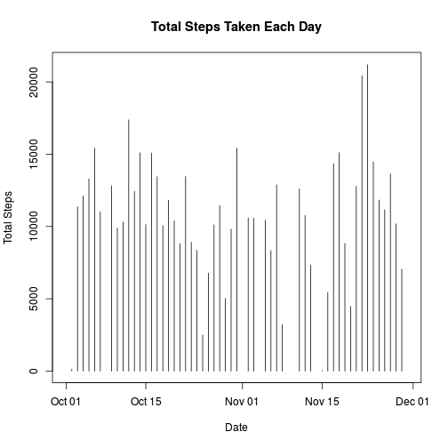

```r
data_steps_sum <- with(data, aggregate(list(Sum_Steps = steps), by=list(Date = date), FUN=sum))
plot(data_steps_sum, type = "h", main = "Total Steps Taken Each Day", xlab = "Date", ylab = "Total Steps")
```

```r
data_steps_mean <- with(data, aggregate(list(Mean_Steps = steps), by=list(Date = date), FUN=mean))
print(data_steps_mean)
```

```
##          Date Mean_Steps
## 1  2012-10-01         NA
## 2  2012-10-02     0.4375
## 3  2012-10-03    39.4167
## 4  2012-10-04    42.0694
## 5  2012-10-05    46.1597
## 6  2012-10-06    53.5417
## 7  2012-10-07    38.2465
## 8  2012-10-08         NA
## 9  2012-10-09    44.4826
## 10 2012-10-10    34.3750
## 11 2012-10-11    35.7778
## 12 2012-10-12    60.3542
## 13 2012-10-13    43.1458
## 14 2012-10-14    52.4236
```

[output cut: 47 more lines]

```r
data_steps_median <- with(data, aggregate(list(Median_Steps = steps), by=list(Date = date), FUN=median, na.rm=TRUE))
print(data_steps_median)
```

```
##          Date Median_Steps
## 1  2012-10-01           NA
## 2  2012-10-02            0
## 3  2012-10-03            0
## 4  2012-10-04            0
## 5  2012-10-05            0
## 6  2012-10-06            0
## 7  2012-10-07            0
## 8  2012-10-08           NA
## 9  2012-10-09            0
## 10 2012-10-10            0
## 11 2012-10-11            0
## 12 2012-10-12            0
## 13 2012-10-13            0
## 14 2012-10-14            0
```

[output cut: 47 more lines]

## What is the average daily activity pattern?

Time series plot of the 5-minute interval and the average number of steps taken, averaged across all days

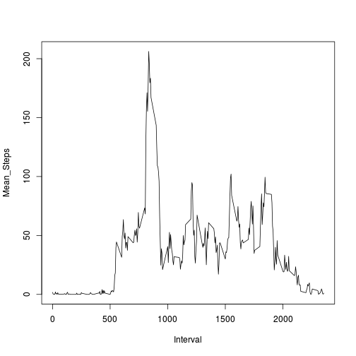

```r
data_interval_mean <- with(data, aggregate(list(Mean_Steps = steps), by=list(Interval = interval), FUN=mean, na.rm=TRUE))
data_interval_mean_plot <- with(data_interval_mean, plot(Interval, Mean_Steps, type="l"))
```

Which 5-minute interval, on average across all the days in the dataset, contains the maximum number of steps?

```r
data[order(data_interval_mean$Mean_Steps, decreasing=TRUE)[1],]$interval
```

```
## [1] "0835"
```

## Imputing missing values

```r
missing_steps = matrix(is.na(data$steps))
missing_steps_count = sum(missing_steps)
```

New dataset that is equal to the original dataset but with the missing data filled in

```r
new_data = data
new_data[missing_steps,]$steps = data_interval_mean$Mean_Steps
```

Histogram of the total number of steps taken each day

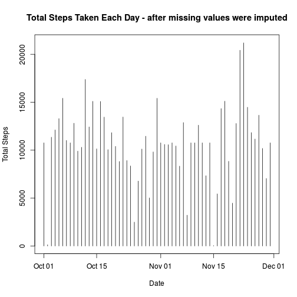

```r
new_data_steps_sum <- with(new_data, aggregate(list(Sum_Steps = steps), by=list(Date = date), FUN=sum))
plot(new_data_steps_sum, type = "h", main = "Total Steps Taken Each Day - after missing values were imputed", xlab = "Date", ylab = "Total Steps")
```

```r
new_data_steps_mean <- with(new_data, aggregate(list(Mean_Steps = steps), by=list(Date = date), FUN=mean, na.rm=TRUE))
print(new_data_steps_mean)
```

```
##          Date Mean_Steps
## 1  2012-10-01    37.3826
## 2  2012-10-02     0.4375
## 3  2012-10-03    39.4167
## 4  2012-10-04    42.0694
## 5  2012-10-05    46.1597
## 6  2012-10-06    53.5417
## 7  2012-10-07    38.2465
## 8  2012-10-08    37.3826
## 9  2012-10-09    44.4826
## 10 2012-10-10    34.3750
## 11 2012-10-11    35.7778
## 12 2012-10-12    60.3542
## 13 2012-10-13    43.1458
## 14 2012-10-14    52.4236
```

[output cut: 47 more lines]

```r
new_data_steps_median <- with(new_data, aggregate(list(Median_Steps = steps), by=list(Date = date), FUN=median, na.rm=TRUE))
print(new_data_steps_median)
```

```
##          Date Median_Steps
## 1  2012-10-01        34.11
## 2  2012-10-02         0.00
## 3  2012-10-03         0.00
## 4  2012-10-04         0.00
## 5  2012-10-05         0.00
## 6  2012-10-06         0.00
## 7  2012-10-07         0.00
## 8  2012-10-08        34.11
## 9  2012-10-09         0.00
## 10 2012-10-10         0.00
## 11 2012-10-11         0.00
## 12 2012-10-12         0.00
## 13 2012-10-13         0.00
## 14 2012-10-14         0.00
```

[output cut: 47 more lines]

## Are there differences in activity patterns between weekdays and weekends?

New factor variable in the dataset with two levels – “weekday” and “weekend” indicating whether a given date is a weekday or weekend day

```r
day_type <- factor(weekdays(new_data$date) %in% c("Saturday", "Sunday"), labels = c("weekday", "weekend"))
new_data = cbind(new_data, day_type)
```

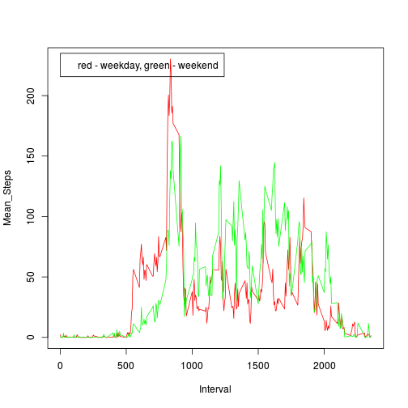

```r
new_data_interval_mean_weekday <- with(new_data[new_data$day_type=="weekday",], aggregate(list(Mean_Steps = steps), by=list(Interval = interval), FUN=mean, na.rm=TRUE))
new_data_interval_mean_weekend <- with(new_data[new_data$day_type=="weekend",], aggregate(list(Mean_Steps = steps), by=list(Interval = interval), FUN=mean, na.rm=TRUE))

plot(new_data_interval_mean_weekday, type="l", col="red")
lines(new_data_interval_mean_weekend, col="green")
legend(x = 235, legend="red - weekday, green - weekend")
```